# Application_Timing

Meghan Duffy

February 26, 2017

## Question: Is there a difference in when men and women first apply for jobs?

Analysis was suggested by an anonymous postdoc, who noted that there appears to be a difference in when men and women first apply for faculty positions, based on data in the 2016-2017 job wiki. First, let’s recreate that figure, using a version of the “anonymous qualifications” page downloaded on February 26, 2017 from: https://docs.google.com/spreadsheets/d/1rOjzt71IBfaz5gYuiVyJxzoCAD8WqM39eUjUhgBEFuU/edit#gid=1893361791

For “# years in postdoc” column: Changed the “< 1” to “0.5” Changed a “4 + 2 as RA” to 6 Changed “3 + 14 alt-ac” to NA

For “# 1st author peer-reviewed papers” column: Changed “13 journal + 15 conference” to NA

For other papers column: Changed “19 journal + 8 conference” to NA

For major grants column: Changed “0 (2 if you count fellowships)” to 0

For years on market: Changed “< 1” to “0.5”

For number applications: removed ~ and just went with number they said for anything else, changed to NA

```r
df <- read.csv("EcoEvoJobApps20162017AnonQualsedited.csv", na.strings = "?")
head(df)
```

```
##   ID                   area.of.specialization             current.position
## 1  3 conservation biology/ quantitative/ etc.                      Postdoc
## 2  7 Applied behavioural ecology/conservation                      Postdoc
## 3  8                          Disease ecology                      Postdoc
## 4 11                    Physiological ecology                      Postdoc
## 5 13                             Macroecology                    Asst Prof
## 6 22                      Behavioural Ecology Postdoc/Sessional Instructor
##   Postdoc Years.in.postdoc X1st.authored.pubs Other.pubs Total.pubs
## 1    2012                4                 19          6         25
## 2    2014                2                  7          2          9
## 3    2014                2                  7         10         17
## 4    2014                2                  8          7         15
## 5    2014                1                 16         12         28
## 6    2014                2                 13          5         18
##   h.index Major.grants Classes.taught Years.on.market Gender Ethnicity
```

[output cut: 48 more lines]

```r
colnames(df)
```

```
##  [1] "ID"
##  [2] "area.of.specialization"
##  [3] "current.position"
##  [4] "Postdoc"
##  [5] "Years.in.postdoc"
##  [6] "X1st.authored.pubs"
##  [7] "Other.pubs"
##  [8] "Total.pubs"
##  [9] "h.index"
## [10] "Major.grants"
## [11] "Classes.taught"
## [12] "Years.on.market"
## [13] "Gender"
## [14] "Ethnicity"
## [15] "Misc"
## [16] "Number.apps"
## [17] "job.searching.result.this.year"
## [18] "X..of.phone.Skype.interviews"
## [19] "X..of.campus.interviews"
## [20] "X..of.rejections"
## [21] "X..of.offers"
## [22] "Frac.schools.you.ve.actually.heard.back.from"
## [23] "Types.of.jobs.applying.for"
## [24] "Comments.q.s.from.others"
```

```r
str(df)
```

```
## 'data.frame':    101 obs. of  24 variables:
##  $ ID                                          : int  3 7 8 11 13 22 23 25 26 28 ...
##  $ area.of.specialization                      : Factor w/ 75 levels "Animal Behavior/Conservation",..: 10 2 12 65 49 6 23 72 29 20 ...
##  $ current.position                            : Factor w/ 26 levels "adjunct research faculty",..: 18 18 18 18 7 19 17 17 17 8 ...
##  $ Postdoc                                     : int  2012 2014 2014 2014 2014 2014 2014 2012 2012 2008 ...
##  $ Years.in.postdoc                            : num  4 2 2 2 1 2 1.5 4 3.5 3 ...
##  $ X1st.authored.pubs                          : int  19 7 7 8 16 13 5 13 7 17 ...
##  $ Other.pubs                                  : int  6 2 10 7 12 5 10 14 4 18 ...
##  $ Total.pubs                                  : int  25 9 17 15 28 18 15 27 11 35 ...
##  $ h.index                                     : Factor w/ 23 levels "","1","1 (google scholar)",..: 5 17 19 19 9 19 18 22 18 10 ...
##  $ Major.grants                                : int  1 3 1 0 3 0 0 1 1 2 ...
##  $ Classes.taught                              : Factor w/ 15 levels ">6","~20","0",..: 7 4 4 7 7 13 4 12 4 12 ...
##  $ Years.on.market                             : num  4 0.5 2 1 1 1 1 3 1 4 ...
##  $ Gender                                      : Factor w/ 2 levels "F","M": 1 1 1 1 1 1 1 1 1 1 ...
##  $ Ethnicity                                   : Factor w/ 8 levels "Asian","Hispanic",..: 6 6 6 6 2 6 6 6 6 6 ...
##  $ Misc                                        : Factor w/ 33 levels "","*only applying to 1 position, currently at NGO",..: 1 22 1 1 14 3 25 1 1 9 ...
##  $ Number.apps                                 : int  54 7 30 41 5 7 18 25 6 50 ...
##  $ job.searching.result.this.year              : Factor w/ 12 levels ""," ","0","1 offer, declined.",..: 1 1 1 1 1 1 7 1 1 9 ...
##  $ X..of.phone.Skype.interviews                : int  5 1 2 10 NA 0 1 11 1 2 ...
##  $ X..of.campus.interviews                     : Factor w/ 11 levels "","0","1","1 offered (I turned it down)",..: 6 4 6 10 1 2 5 7 5 3 ...
##  $ X..of.rejections                            : Factor w/ 22 levels "","1","10","11",..: 8 2 8 6 1 18 17 17 2 17 ...
##  $ X..of.offers                                : int  0 NA 1 NA NA 0 1 NA 1 1 ...
##  $ Frac.schools.you.ve.actually.heard.back.from: Factor w/ 38 levels "","0","0.14",..: 9 1 1 1 1 26 33 34 36 22 ...
##  $ Types.of.jobs.applying.for                  : Factor w/ 61 levels "","any level that still allows research",..: 57 18 38 13 1 30 51 34 34 15 ...
##  $ Comments.q.s.from.others                    : Factor w/ 25 levels "","1 \"long list\" but that's it. ",..: 21 5 23 1 1 1 7 1 1 1 ...
```

### Make figure based on one that was sent to me (Year PhD of applicants by gender)

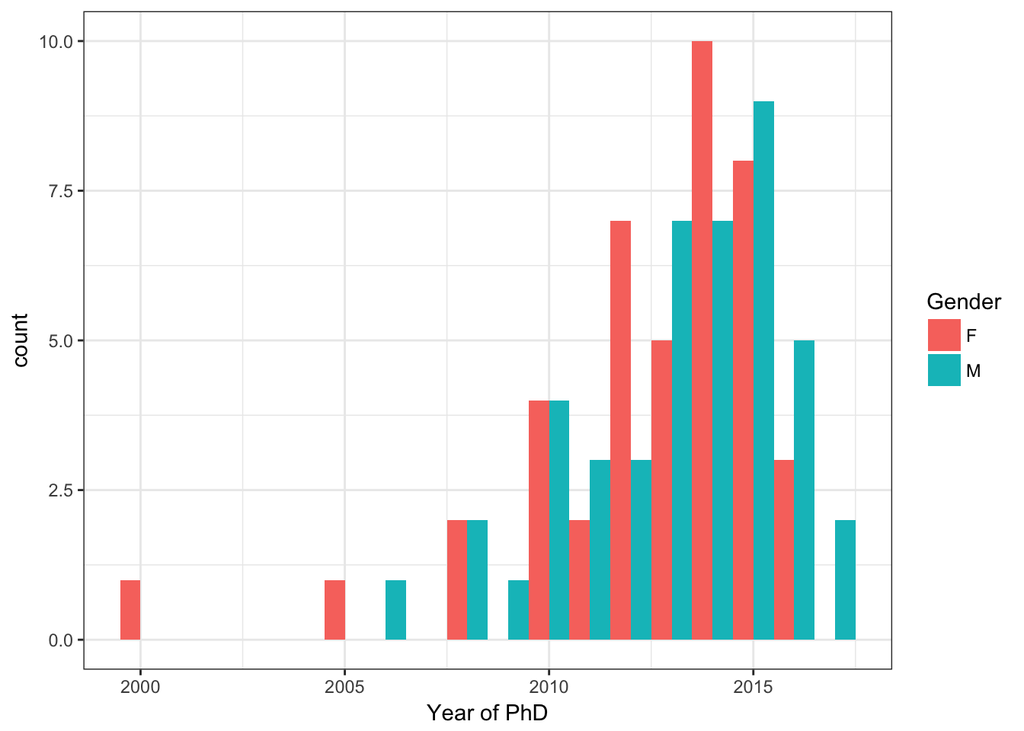

```r
YearGender <-
  df %>%
  filter(!is.na(Postdoc)) %>%
  filter(Number.apps >0) %>%
  group_by(Gender,Postdoc) %>%
  summarise(n=n()) %>%
  mutate(rel.freq = round(100 * n/sum(n), 0))

yeargenderplot <- df %>%
  filter(!is.na(Postdoc)) %>%
  filter(Number.apps >0) %>%
  ggplot(aes(x = Postdoc, fill=Gender)) +
  geom_histogram(binwidth=1.0, boundary=-0.5, position="dodge") +
  xlab("Year of PhD") +
  theme_bw()

yeargenderplot
```

```r
save_plot("yeargenderplot.jpg", yeargenderplot, base_height=4, base_width = 6)
```

### Looking at years on market

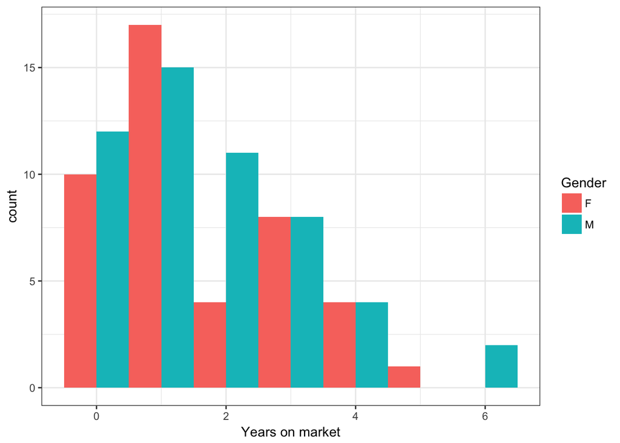

```r
yearsonmarketplot <- df %>%
  filter(!is.na(Years.on.market)) %>%
  ggplot(aes(x = Years.on.market, fill=Gender)) +
  geom_histogram(binwidth=1.0, boundary=-0.5, position="dodge") +
  xlab("Years on market") +
  theme_bw()

yearsonmarketplot
```

### Does the year gender plot pattern hold for 2015-2016?

```r
df2015 <- read.csv("EcoEvoJobApps20152016AnonQualsedited.csv", na.strings = "?")
head(df)
```

```
##   ID                   area.of.specialization             current.position
## 1  3 conservation biology/ quantitative/ etc.                      Postdoc
## 2  7 Applied behavioural ecology/conservation                      Postdoc
## 3  8                          Disease ecology                      Postdoc
## 4 11                    Physiological ecology                      Postdoc
## 5 13                             Macroecology                    Asst Prof
## 6 22                      Behavioural Ecology Postdoc/Sessional Instructor
##   Postdoc Years.in.postdoc X1st.authored.pubs Other.pubs Total.pubs
## 1    2012                4                 19          6         25
## 2    2014                2                  7          2          9
## 3    2014                2                  7         10         17
## 4    2014                2                  8          7         15
## 5    2014                1                 16         12         28
## 6    2014                2                 13          5         18
##   h.index Major.grants Classes.taught Years.on.market Gender Ethnicity
```

[output cut: 48 more lines]

```r
colnames(df)
```

```
##  [1] "ID"
##  [2] "area.of.specialization"
##  [3] "current.position"
##  [4] "Postdoc"
##  [5] "Years.in.postdoc"
##  [6] "X1st.authored.pubs"
##  [7] "Other.pubs"
##  [8] "Total.pubs"
##  [9] "h.index"
## [10] "Major.grants"
## [11] "Classes.taught"
## [12] "Years.on.market"
## [13] "Gender"
## [14] "Ethnicity"
## [15] "Misc"
## [16] "Number.apps"
## [17] "job.searching.result.this.year"
## [18] "X..of.phone.Skype.interviews"
## [19] "X..of.campus.interviews"
## [20] "X..of.rejections"
## [21] "X..of.offers"
## [22] "Frac.schools.you.ve.actually.heard.back.from"
## [23] "Types.of.jobs.applying.for"
## [24] "Comments.q.s.from.others"
```

```r
str(df)
```

```
## 'data.frame':    101 obs. of  24 variables:
##  $ ID                                          : int  3 7 8 11 13 22 23 25 26 28 ...
##  $ area.of.specialization                      : Factor w/ 75 levels "Animal Behavior/Conservation",..: 10 2 12 65 49 6 23 72 29 20 ...
##  $ current.position                            : Factor w/ 26 levels "adjunct research faculty",..: 18 18 18 18 7 19 17 17 17 8 ...
##  $ Postdoc                                     : int  2012 2014 2014 2014 2014 2014 2014 2012 2012 2008 ...
##  $ Years.in.postdoc                            : num  4 2 2 2 1 2 1.5 4 3.5 3 ...
##  $ X1st.authored.pubs                          : int  19 7 7 8 16 13 5 13 7 17 ...
##  $ Other.pubs                                  : int  6 2 10 7 12 5 10 14 4 18 ...
##  $ Total.pubs                                  : int  25 9 17 15 28 18 15 27 11 35 ...
##  $ h.index                                     : Factor w/ 23 levels "","1","1 (google scholar)",..: 5 17 19 19 9 19 18 22 18 10 ...
##  $ Major.grants                                : int  1 3 1 0 3 0 0 1 1 2 ...
##  $ Classes.taught                              : Factor w/ 15 levels ">6","~20","0",..: 7 4 4 7 7 13 4 12 4 12 ...
##  $ Years.on.market                             : num  4 0.5 2 1 1 1 1 3 1 4 ...
##  $ Gender                                      : Factor w/ 2 levels "F","M": 1 1 1 1 1 1 1 1 1 1 ...
##  $ Ethnicity                                   : Factor w/ 8 levels "Asian","Hispanic",..: 6 6 6 6 2 6 6 6 6 6 ...
##  $ Misc                                        : Factor w/ 33 levels "","*only applying to 1 position, currently at NGO",..: 1 22 1 1 14 3 25 1 1 9 ...
##  $ Number.apps                                 : int  54 7 30 41 5 7 18 25 6 50 ...
##  $ job.searching.result.this.year              : Factor w/ 12 levels ""," ","0","1 offer, declined.",..: 1 1 1 1 1 1 7 1 1 9 ...
##  $ X..of.phone.Skype.interviews                : int  5 1 2 10 NA 0 1 11 1 2 ...
##  $ X..of.campus.interviews                     : Factor w/ 11 levels "","0","1","1 offered (I turned it down)",..: 6 4 6 10 1 2 5 7 5 3 ...
##  $ X..of.rejections                            : Factor w/ 22 levels "","1","10","11",..: 8 2 8 6 1 18 17 17 2 17 ...
##  $ X..of.offers                                : int  0 NA 1 NA NA 0 1 NA 1 1 ...
##  $ Frac.schools.you.ve.actually.heard.back.from: Factor w/ 38 levels "","0","0.14",..: 9 1 1 1 1 26 33 34 36 22 ...
##  $ Types.of.jobs.applying.for                  : Factor w/ 61 levels "","any level that still allows research",..: 57 18 38 13 1 30 51 34 34 15 ...
##  $ Comments.q.s.from.others                    : Factor w/ 25 levels "","1 \"long list\" but that's it. ",..: 21 5 23 1 1 1 7 1 1 1 ...
```

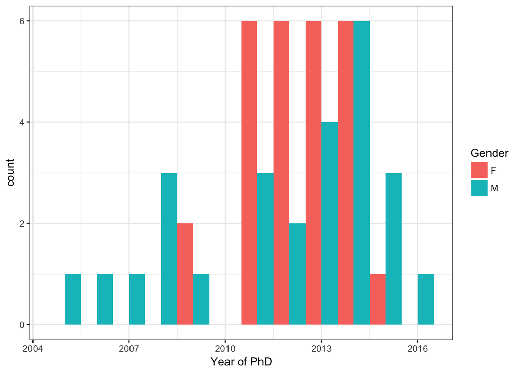

```r
YearGender2015 <-
  df2015 %>%
  filter(!is.na(PhD.year)) %>%
  filter(Number.apps >0) %>%
  group_by(Gender,PhD.year) %>%
  summarise(n=n()) %>%
  mutate(rel.freq = round(100 * n/sum(n), 0))

yeargenderplot2015 <- df2015 %>%
  filter(!is.na(PhD.year)) %>%
  filter(!is.na(Gender)) %>%
  filter(Number.apps >0) %>%
  ggplot(aes(x = PhD.year, fill=Gender)) +
  geom_histogram(binwidth=1.0, boundary=-0.5, position="dodge") +
  xlab("Year of PhD") +
  theme_bw()

yeargenderplot2015
```

```r
save_plot("yeargenderplot2015.jpg", yeargenderplot2015, base_height=4, base_width = 6)
```

## Moving on to look at data from Dynamic Ecology poll

Poll: https://dynamicecology.wordpress.com/2017/02/27/poll-what-determines-when-people-start-applying-for-jobs/

Note: I deleted the data on whether people were from underrepresented groups from the version of the spreadsheet I put on github. There were so few people in several of the categories that I was concerned that it might be possible to identify individuals (e.g., if someone from one of those groups had told a friend they had filled out the survey).

```r
polldf <- read.csv("JobAppPolltrimmed.csv", na.strings = "?")
head(polldf)
```

```
##            Timestamp When.did.you.get.your.PhD. PhD01
## 1 2/27/2017 11:39:16                       2015  2015
## 2 2/27/2017 17:10:42                       2007  2007
## 3 2/28/2017 14:10:21                       2013  2013
## 4 2/27/2017 10:42:54                       2015  2015
## 5 2/27/2017 11:16:22                       2015  2015
## 6   3/3/2017 7:39:33                       2012  2012
##   In.what.year.did.you.first.apply.for.tenure.track.positions.or.their.equivalents...Give.your.answer.in.terms.of.years.post.PhD..if.you.applied.while.still.a.PhD.student..choose..0..
## 1                                                                                                                                                                                     1
## 2                                                                                                                                                                                     0
## 3                                                                                                                                                                 I haven't applied yet
## 4                                                                                                                                                                                     2
## 5                                                                                                                                                                                     1
## 6                                                                                                                                                                                     2
##   FirstApplied01 FirstApplied01NY
```

[output cut: 48 more lines]

```r
colnames(polldf)
```

```
##  [1] "Timestamp"
##  [2] "When.did.you.get.your.PhD."
##  [3] "PhD01"
##  [4] "In.what.year.did.you.first.apply.for.tenure.track.positions.or.their.equivalents...Give.your.answer.in.terms.of.years.post.PhD..if.you.applied.while.still.a.PhD.student..choose..0.."
##  [5] "FirstApplied01"
##  [6] "FirstApplied01NY"
##  [7] "In.what.year.did.you.get.your.first.on.campus.interview...Give.your.answer.in.terms.of.years.post.PhD..if.it.was.while.you.were.still.a.PhD.student..choose..0.."
##  [8] "FirstInterview01"
##  [9] "FirstInterview01NY"
## [10] "In.what.year.did.you.get.your.first.tenure.track.job.offer...Give.your.answer.in.terms.of.years.post.PhD..if.it.was.while.you.were.still.a.PhD.student..choose..0.."
## [11] "FirstOffer01"
## [12] "FirstOffer01NY"
## [13] "Which.of.the.following.options.made.you.decide.to.wait.a.year..or.more..to.apply...Choose.up.to.3."
## [14] "Gender"
```

```r
str(polldf)
```

```
## 'data.frame':    405 obs. of  14 variables:
##  $ Timestamp                                                                                                                                                                            : Factor w/ 401 levels "2/27/2017 10:00:10",..: 77 191 301 43 65 384 355 26 245 190 ...
##  $ When.did.you.get.your.PhD.                                                                                                                                                           : Factor w/ 24 levels "1996","1997",..: 20 12 18 20 20 17 18 NA 22 19 ...
##  $ PhD01                                                                                                                                                                                : int  2015 2007 2013 2015 2015 2012 2013 NA 2017 2014 ...
##  $ In.what.year.did.you.first.apply.for.tenure.track.positions.or.their.equivalents...Give.your.answer.in.terms.of.years.post.PhD..if.you.applied.while.still.a.PhD.student..choose..0..: Factor w/ 10 levels "0","1","10 or more",..: 2 1 10 4 2 4 10 5 1 2 ...
##  $ FirstApplied01                                                                                                                                                                       : int  1 0 NA 2 1 2 NA 3 0 1 ...
##  $ FirstApplied01NY                                                                                                                                                                     : Factor w/ 10 levels "0","1","10","2",..: 2 1 10 4 2 4 10 5 1 2 ...
##  $ In.what.year.did.you.get.your.first.on.campus.interview...Give.your.answer.in.terms.of.years.post.PhD..if.it.was.while.you.were.still.a.PhD.student..choose..0..                     : Factor w/ 11 levels "0","1","10 or more",..: 2 1 11 4 2 4 NA 11 NA 2 ...
##  $ FirstInterview01                                                                                                                                                                     : int  1 0 NA 2 1 2 NA NA NA 1 ...
##  $ FirstInterview01NY                                                                                                                                                                   : Factor w/ 11 levels "0","1","10","2",..: 2 1 11 4 2 4 NA 11 NA 2 ...
##  $ In.what.year.did.you.get.your.first.tenure.track.job.offer...Give.your.answer.in.terms.of.years.post.PhD..if.it.was.while.you.were.still.a.PhD.student..choose..0..                  : Factor w/ 12 levels "0","1","10 or more",..: 12 1 12 4 4 5 NA 12 NA 4 ...
##  $ FirstOffer01                                                                                                                                                                         : int  NA 0 NA 2 2 3 NA NA NA 2 ...
##  $ FirstOffer01NY                                                                                                                                                                       : Factor w/ 12 levels "0","1","10","2",..: 12 1 12 4 4 5 NA 12 NA 4 ...
##  $ Which.of.the.following.options.made.you.decide.to.wait.a.year..or.more..to.apply...Choose.up.to.3.                                                                                   : Factor w/ 174 levels "advice from other mentors, already committed to a fixed term position (e.g., a postdoctor…
##  $ Gender                                                                                                                                                                               : Factor w/ 3 levels "Female","Male",..: 2 2 1 1 2 1 1 1 1 1 ...
```

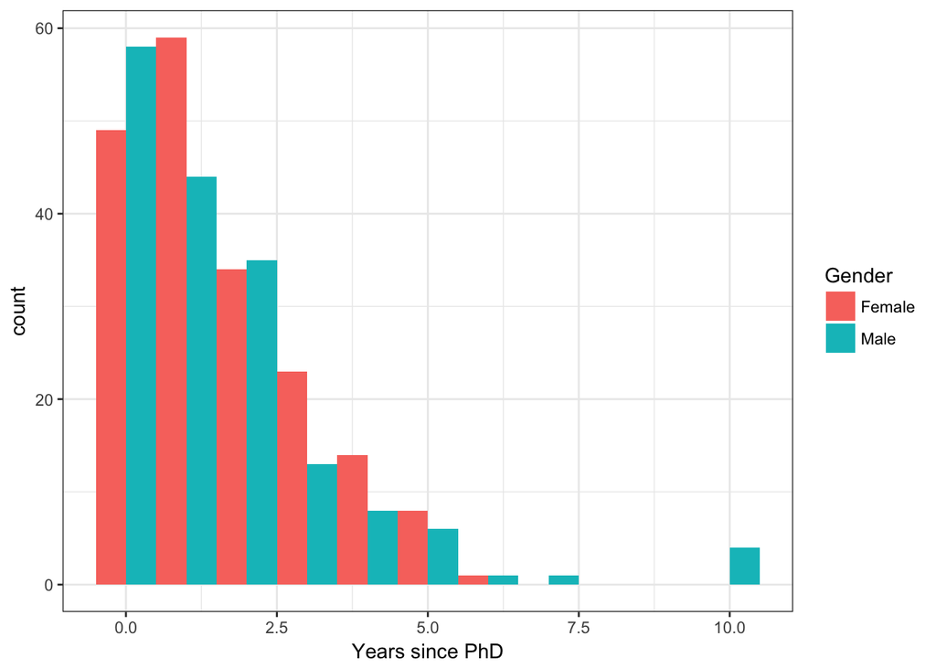

```r
PollGenderAllYears <-
  polldf %>%
  filter(!is.na(FirstApplied01)) %>%
  filter(Gender==c("Male") | Gender==c("Female")) %>%
  group_by(Gender,FirstApplied01) %>%
  summarise(n=n()) %>%
  mutate(rel.freq = round(100 * n/sum(n), 0))

yeargenderplotpollallyears <- polldf %>%
  filter(!is.na(FirstApplied01)) %>%
  filter(Gender==c("Male") | Gender==c("Female")) %>%
  ggplot(aes(x = FirstApplied01, fill=Gender)) +
  geom_histogram(binwidth=1.0, boundary=-0.5, position="dodge") +
  xlab("Years since PhD") +
  theme_bw()

yeargenderplotpollallyears
```

```r
save_plot("yeargenderplotpollallyears.jpg", yeargenderplotpollallyears, base_height=4, base_width = 6)
```

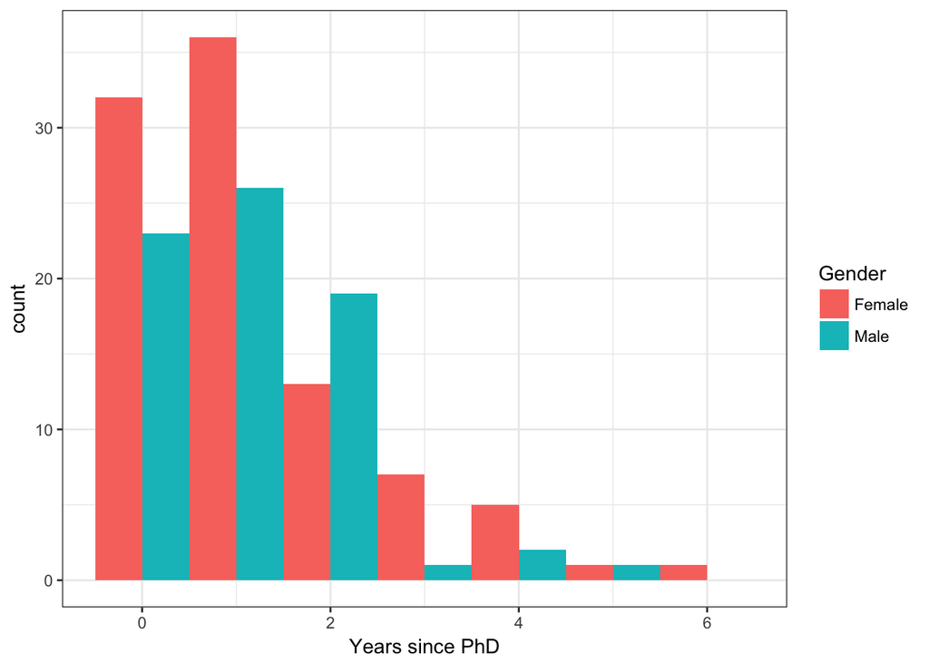

```r
PollGenderLast5Years <-
  polldf %>%
  filter(!is.na(FirstApplied01)) %>%
  filter(Gender==c("Male") | Gender==c("Female")) %>%
  filter(PhD01 > 2011) %>%
  group_by(Gender,FirstApplied01) %>%
  summarise(n=n()) %>%
  mutate(rel.freq = round(100 * n/sum(n), 0))

yeargenderplotpolllast5years <- polldf %>%
  filter(!is.na(FirstApplied01)) %>%
  filter(Gender==c("Male") | Gender==c("Female")) %>%
  filter(PhD01 > 2011) %>%
  ggplot(aes(x = FirstApplied01, fill=Gender)) +
  geom_histogram(binwidth=1.0, boundary=-0.5, position="dodge") +
  xlab("Years since PhD") +
  theme_bw()

yeargenderplotpolllast5years
```

```r
save_plot("yeargenderplotpolllast5years.jpg", yeargenderplotpolllast5years, base_height=4, base_width = 6)
```